# Design and Analysis of Algorithms - Naiara Alonso Montes

## Exercise 1

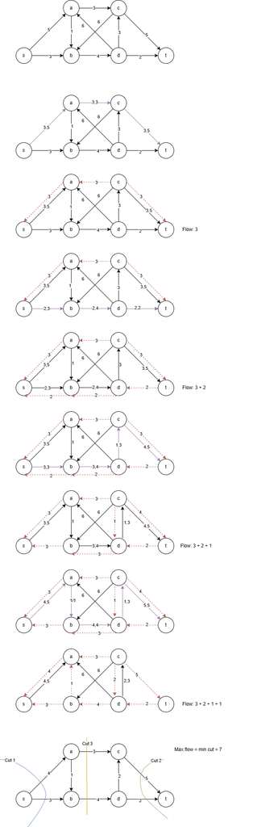

The maximal flow is equal to 7, same to the value of the minimum cut. I found 3 minimum cuts.

## Exercise 2

Assume $P_1$ as the first augmented path found by Ford-Fulkerson algorithm, with $V_1$ vertices and $E_1$ edges. $$E_1 = {e_0, e_1, ..., e_n}$$ $$|E_1| ≥ 4$$ $$d_1(t) = |E_1|$$

Assume $P_2$ as the second augmented path found, with $V_2$ vertices and $E_2$ edges such that: $$E_2 = E_1 ∉ e_1$$ $$|E_2| = |E_1| - 1$$ $$d_2(t) = |E_2|$$

After second iteration we found that: $$d_1(t) = |E_1| > |E_1| - 1 = d_2(t)$$

Thus, in Ford-Fulkerson algorithm the distance $d(v)$ can decrease. This is because the algorithm does not follow any especific search principle and the first found path can be the maximal in terms of distance.

## Exercise 3

### Edge in all minimum cuts

**Statement:**

If an edge belongs to all minumum cuts, removing it will increase the cut value.

**Algorithm:**

1. Find the maximum flow, for example with Edmonds-Karp.
2. Remove the edge of the network and recompute maximum flow.
3. Compare flows, if the new maximum flow is less than the original maximum flow, then $e$ belongs to all minimum cuts. Otherwise, it is not.

**Correctness:**

- If removing $e$ increases the minimum cut value, it means that edge $e$ was part of all minimum cuts.
- If removing edge $e$ does not change the minimum cut value, it means that there was another path that could carry the same flow, so $e$ is not in all minimum cuts.

**Time complexity:**

The time complexity for this algorithm is the same as the time complexity used for finding the maximum flow.

### Edge in some minimum cut

**Statement:**

If an edge is in some minimum cut, reducing its capacity will increase the minimum cut value.

**Algorithm:**

1. Find the maximum flow.
2. Reduce capacity of edge in $ϵ$.
3. Recompute maximum flow.
4. Compare, if new maximum flow is less than the original flow, then $e$ is in some minimum cut. Otherwise it is not.

**Correctness:**

- If reducing the capacity of $e$ increases the minimum cut value, then $e$ was part of some minimum cut.
- If reducing the capacity does not change the value of the minumum cut, then there are other paths that can carry the increased flow, so $e$ is not in any minimum cut.

**Time complexity:**

The time complexity for this algorithm is the same as the time complexity used for finding the maximum flow.

```python
!jupyter nbconvert --to html HW2.ipynb
```